# Latihan 6 MPDW

## Library

```r
library(forecast)
```

```r
library(ggplot2)
library(tsibble)
library(tseries)
library(TSA)
library(TTR)
library(aTSA)
library(MASS)
```

## Import Data

```r
data <- read.csv("D:\\File\\Data Science\\Semester 5\\MPDW\\Data MPDW Kelompok 1.csv")
df <- data[126:250, ]
df
```

```
##           Date     Close    Volume
## 126 2024-04-22  7619.253  23379200
## 127 2024-04-23  7294.498  14117500
## 128 2024-04-24  7968.989  16627200
## 129 2024-04-25  8268.763  16941200
## 130 2024-04-26  8618.499  36478400
## 131 2024-04-29  9018.197  17974400
## 132 2024-04-30  9218.047  24471600
## 133 2024-05-02  9867.557  22657200
## 134 2024-05-03  9867.557         0
## 135 2024-05-06  9292.990  13332100
## 136 2024-05-07  9867.557  13495400
## 137 2024-05-08  9642.727  12895300
## 138 2024-05-13  9442.877  12510700
## 139 2024-05-14  9268.010  11060200
```

[output cut: 111 more lines]

Data yang digunakan adalah data saham BREN hari ke-126 hingga hari ke-250

## Eksplorasi Data

### Plot Data Penuh

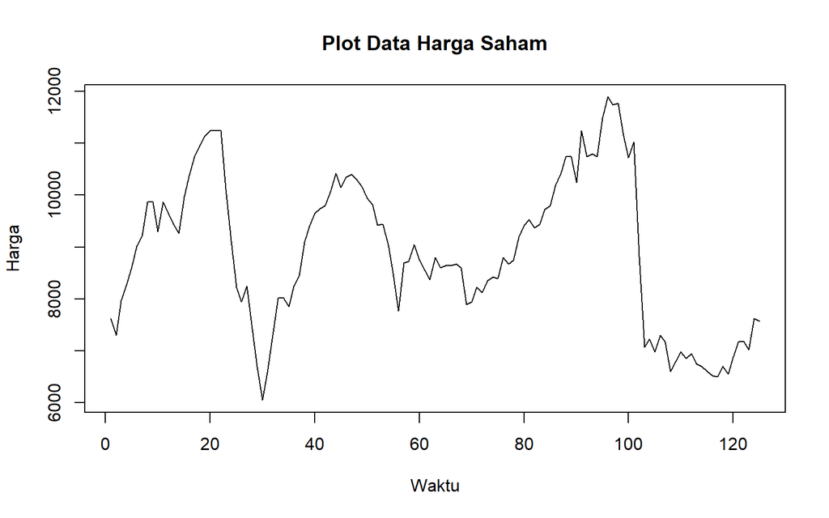

```r
dt <- ts(df$Close)

plot.ts(dt,
        lty = 1,
        xlab = "Waktu",
        ylab = "Harga",
        main = "Plot Data Harga Saham")
```

Berdasarkan plot data deret waktu, terlihat bahwa data cenderung memiliki trend yang fluktuatif. Berdasarkan pola data, pembagian data latih dan data uji ditetapkan dengan proporsi 84% : 16%.

### Plot Data Latih

```r
dt.train <- df$Close[1:105]
train.ts <- ts(dt.train)
```

```r
mean <- mean(train.ts)
mean
```

```
## [1] 9274.564
```

```r
var(train.ts)
```

```
## [1] 1605706
```

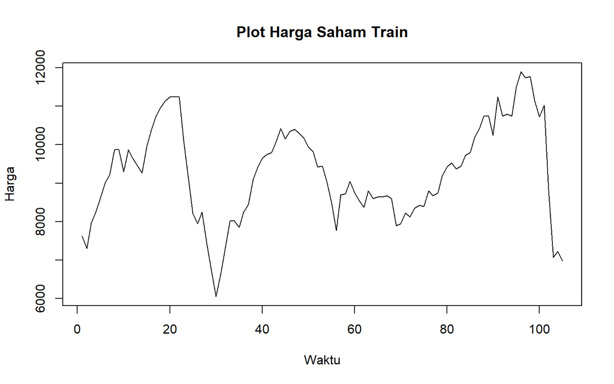

```r
plot.ts(train.ts, lty=1, xlab="Waktu", ylab="Harga", main="Plot Harga Saham Train")
```

Berdasarkan plot data deret waktu pada data latih, terlihat bahwa data tidak stasioner baik dalam rataan yang ditandai dengan adanya tren yang berfluktuasi dan jauh dari nilai rataannya $9274.564$ serta dalam ragam, yang ditandai dengan perbedaan pelebaran pita pada plot.

### Plot Data Uji

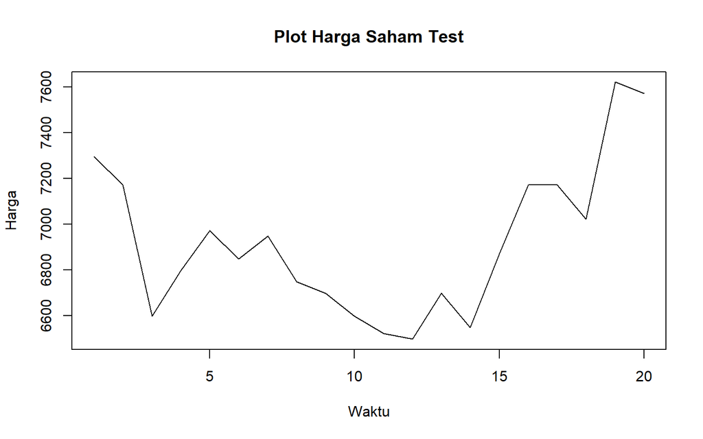

```r
dt.test <- df$Close[106:125]
test.ts <- ts(dt.test)
plot.ts(test.ts, lty=1, xlab="Waktu", ylab="Harga", main="Plot Harga Saham Test")
```

## Pemeriksaan Kestasioneran Data

### Kestasioneran dalam Rataan

#### Plot Time Series

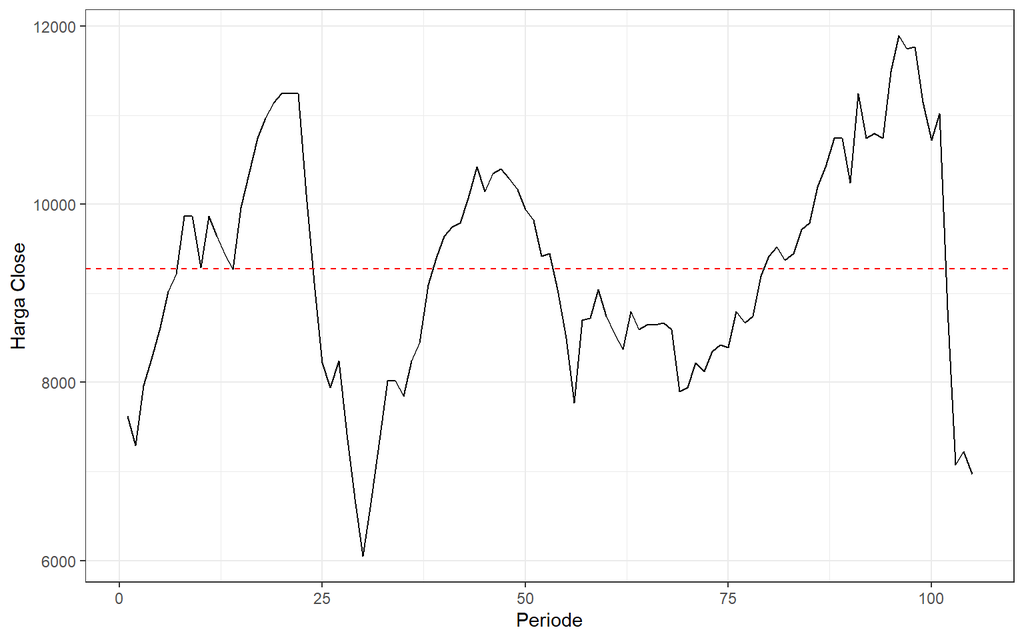

```r
plot <- train.ts |> as_tsibble() |>
  ggplot(aes(x = index, y = value)) + geom_line() + theme_bw() +
  geom_hline(yintercept = mean, color = "red", linetype = "dashed") +
  xlab("Periode") + ylab("Harga Close")
plot
```

Pada plot deret waktu diatas terlihat bahwa data tidak stasioner baik dalam rataan yang ditandai dengan adanya tren yang berfluktuasi dan jauh dari nilai rataannya $9274.564$ serta dalam ragam, yang ditandai dengan perbedaan pelebaran pita pada plot.

#### Plot ACF

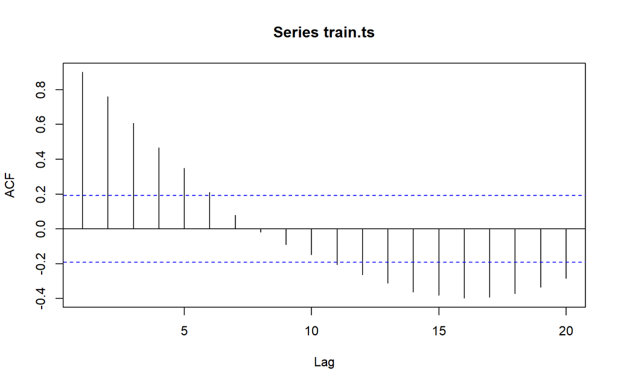

```r
acf(train.ts)
```

Terlihat bahwa plot ACF diatas membentuk pola tails off dan cenderung membentuk pola grafik sinus. Dari plot ini diperlukan adanya uji lanjut untuk memastikan kestasioneran datanya.

#### Uji ADF

$H_0:Data \ Tidak \ Stasioner \ dalam \ Rataan$  
$H_1:Data \ Stasioner \ dalam \ Rataan$

```r
tseries::adf.test(train.ts)
```

```
##
##  Augmented Dickey-Fuller Test
##
## data:  train.ts
## Dickey-Fuller = -3.1664, Lag order = 4, p-value = 0.09718
## alternative hypothesis: stationary
```

Hasil Uji ADF memperlihatkan nilai $p-value$ sebesar $0.09718$ yang lebih besar dari $\alpha=0.05$ sehingga Tak Tolak $H_0$ yang artinya data tidak stasioner dalam rataan, sesuai dengan plot ACF diatas.

### Kestasioneran dalam Ragam

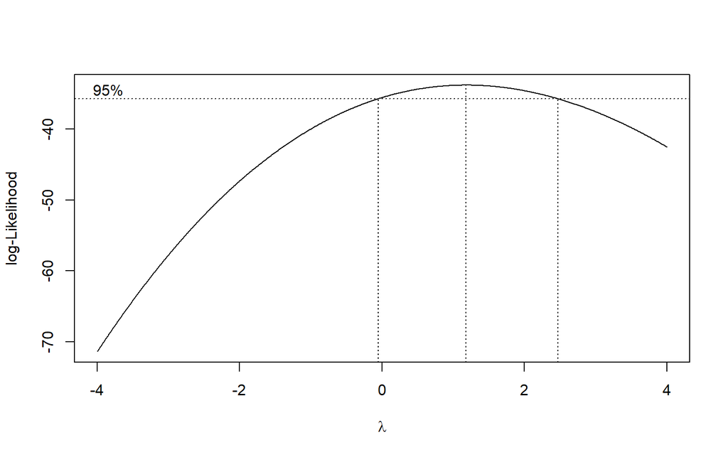

```r
index <- seq(126:230)
bc = boxcox(train.ts~index, lambda = seq(-4,4,by=0.01))
```

```r
lambda <- bc$x[which.max(bc$y)]
lambda
```

```
## [1] 1.18
```

```r
ci_lambda <- bc$x[bc$y > max(bc$y) - 0.5 * qchisq(0.95, 1)]

ci_lower <- min(ci_lambda)
ci_upper <- max(ci_lambda)

c(Batas_Bawah = ci_lower, Batas_Atas = ci_upper)
```

```
## Batas_Bawah  Batas_Atas
##       -0.05        2.46
```

Hasil uji Box–Cox menunjukkan bahwa nilai $λ$ optimum adalah $1.18$. Pada selang kepercayaan diatas terlihat bahwa nilai batas bawah sebesar $-0.05$ dan batas atas sebesar $2.46$, sehingga nilai $\lambda=1$ berada dalam selang tersebut, artinya data stasioner dalam ragam.

## Penanganan Ketidakstasioneran Data

### Differencing I

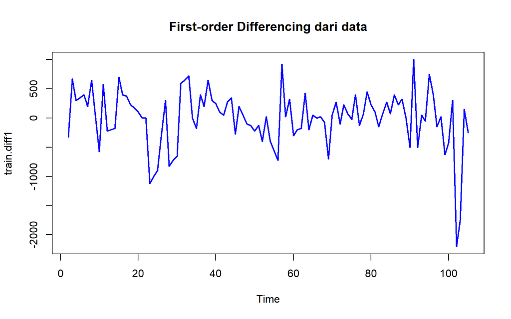

```r
train.diff1 <- diff(train.ts, differences = 1)

ts.plot(train.diff1,
        main = "First-order Differencing dari data",
        col = "blue", lwd = 2)
```

```r
length(train.diff1)
```

```
## [1] 104
```

Setelah dilakukan proses differencing, terlihat bahwa data cenderung stasioner dalam rataan tetapi ada beberapa yang masih jauh dari rataannya, sehingga hal tersebut masih perlu dipastikan melalui plot ACF dan Uji ADF.

#### Plot ACF setelah Differencing I

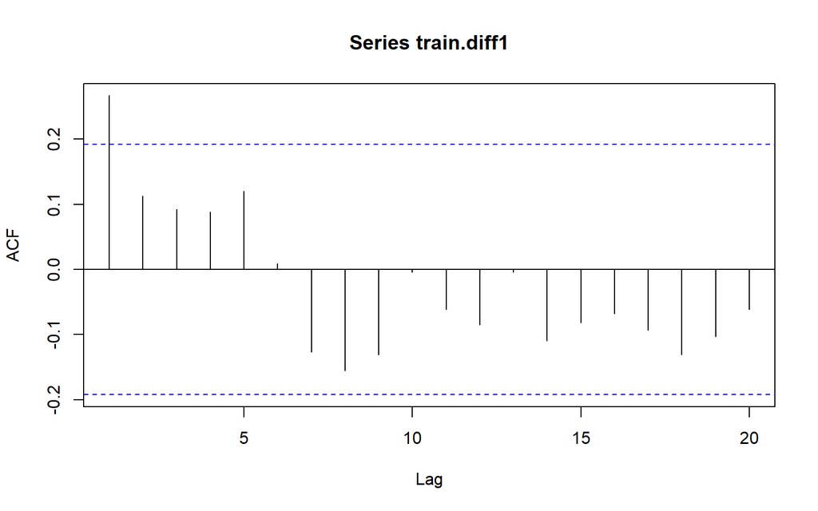

```r
acf(train.diff1)
```

#### Uji ADF setelah Differencing I

```r
tseries::adf.test(train.diff1)
```

```
##
##  Augmented Dickey-Fuller Test
##
## data:  train.diff1
## Dickey-Fuller = -2.7473, Lag order = 4, p-value = 0.2668
## alternative hypothesis: stationary
```

Hasil Uji ADF memperlihatkan nilai $p-value$ sebesar $0.2668$ yang masih lebih besar dari $\alpha=0.05$ sehingga Tak Tolak $H_0$ yang artinya data masih tidak stasioner dalam rataan.

### Differencing II

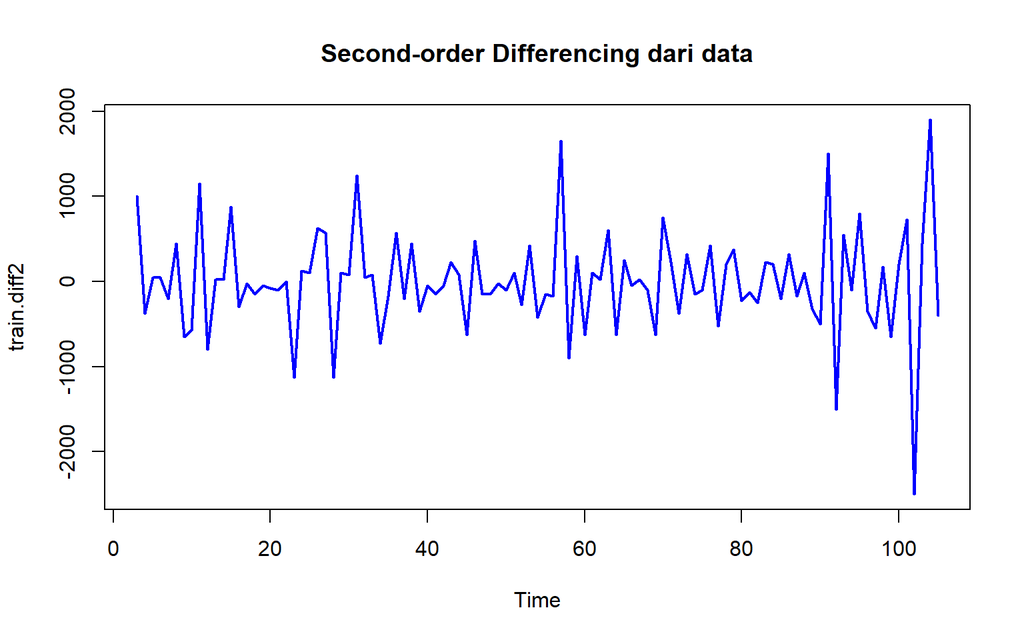

```r
train.diff2 <- diff(train.ts, differences = 2)

ts.plot(train.diff2,
        main = "Second-order Differencing dari data",
        col = "blue", lwd = 2)
```

#### Plot ACF setelah Differencing II

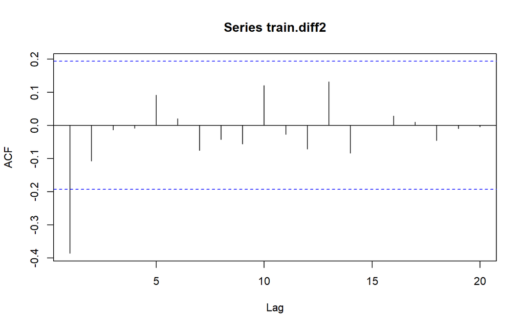

```r
acf(train.diff2)
```

Pada plot ACF diatas terlihat bahwa plot tidak mengalami penurunan perlahan (tails off), hanya saja masih signifikan pada lag ke-1, tetapi secara keseluruhan plot ACF ini menggambarkan bahwa data sudah stasioner dalam rataan yang akan dibuktikan pada uji ADF.

#### Uji ADF setelah Differencing II

```r
tseries::adf.test(train.diff2)
```

```
##
##  Augmented Dickey-Fuller Test
##
## data:  train.diff2
## Dickey-Fuller = -6.5985, Lag order = 4, p-value = 0.01
## alternative hypothesis: stationary
```

Hasil Uji ADF memperlihatkan nilai $p-value$ sebesar $0.01$ yang lebih kecil dari $\alpha=0.05$ sehingga Tolak $H_0$ yang artinya data stasioner dalam rataan, hal ini sesuai dengan plot ACF diatas.

### Kestasioneran dalam Ragam setelah Penanganan

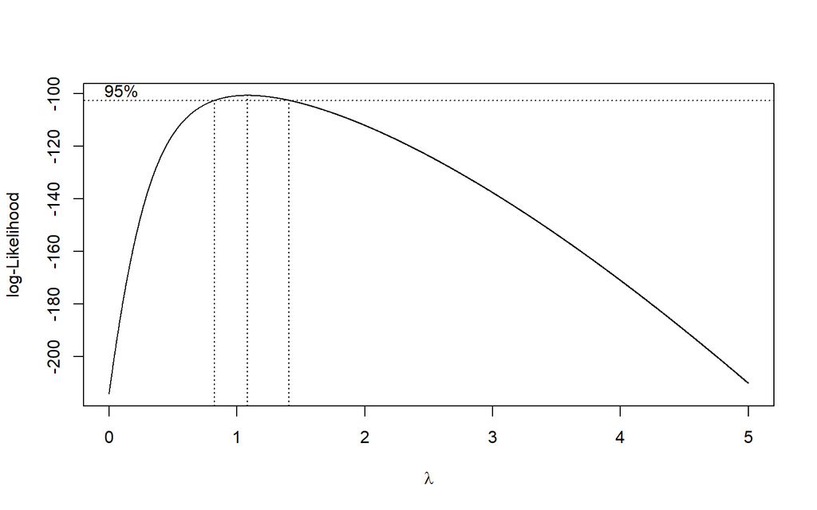

```r
index2 <- seq(126:228)

bc <- boxcox(
  train.diff2 - min(train.diff2) + 1 ~ index2,
  lambda = seq(0, 5, by = 0.001)
)
```

```r
lambda <- bc$x[which.max(bc$y)]
lambda
```

```
## [1] 1.081
```

```r
ci_lambda <- bc$x[bc$y > max(bc$y) - 0.5 * qchisq(0.95, 1)]

ci_lower <- min(ci_lambda)
ci_upper <- max(ci_lambda)

c(Batas_Bawah = ci_lower, Batas_Atas = ci_upper)
```

```
## Batas_Bawah  Batas_Atas
##       0.823       1.407
```

Hasil uji Box–Cox menunjukkan bahwa nilai $λ$ optimum adalah $1.081$. Pada selang kepercayaan diatas terlihat bahwa nilai batas bawah sebesar $0.823$ dan batas atas sebesar $1.407$, sehingga nilai $\lambda=1$ berada dalam selang tersebut, artinya data stasioner dalam ragam.

## Identifikasi Model

### Plot ACF

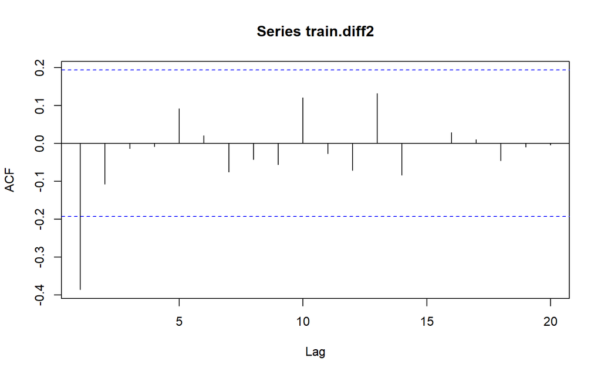

```r
acf(train.diff2)
```

Berdasarkan plot tersebut, terlihat bahwa plot ACF cenderung cuts off pada lag ke 1, sehingga jika plot PACF dianggap tails of, maka model tentatifnya adalah ARIMA(0,2,1).

### Plot PACF

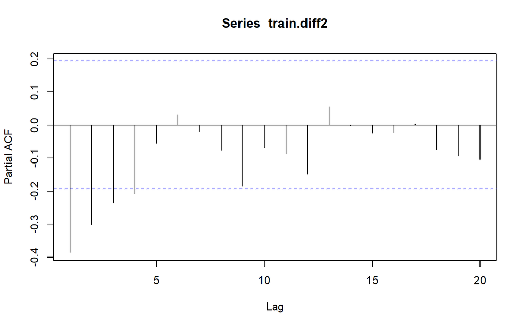

```r
pacf(train.diff2)
```

Berdasarkan plot tersebut, terlihat bahwa plot PACF cenderung cuts off pada lag ke 4, sehingga jika plot ACF dianggap tails of, maka model tentatifnya adalah ARIMA(4,2,0).

Jika baik plot ACF maupun plot PACF keduanya dianggap tails of, maka model yang terbentuk adalah ARIMA(1,2,1)

### Plot EACF

```r
eacf(train.diff2)
```

```
## AR/MA
##   0 1 2 3 4 5 6 7 8 9 10 11 12 13
## 0 x o o o o o o o o o o  o  o  o
## 1 x o o o o o o o o o o  o  o  o
## 2 x x o o o o o o o o o  o  o  o
## 3 x o o o o o o o o o o  o  o  o
## 4 o x o o o o o o o o o  o  o  o
## 5 x x o o o o o o o o o  o  o  o
## 6 o x o o o o o o o o o  o  o  o
## 7 o o o o o o o o o o o  o  o  o
```

Identifikasi model tentatif yang terbentuk menggunakan plot EACF adalah ARIMA(0,2,1), ARIMA(1,2,1), ARIMA(2,2,2), dan ARIMA(3,2,1)

## Pendugaan Parameter Model Tentatif

### ARIMA(0,2,1)

```r
model1 = Arima(train.diff2, order=c(0,0,1), method="ML")
summary(model1)
```

```
## Series: train.diff2
## ARIMA(0,0,1) with non-zero mean
##
## Coefficients:
##           ma1     mean
##       -0.7948  -7.1715
## s.e.   0.0833  10.4028
##
## sigma^2 = 248431:  log likelihood = -785.42
## AIC=1576.84   AICc=1577.08   BIC=1584.75
##
## Training set error measures:
##                    ME     RMSE      MAE  MPE MAPE      MASE      ACF1
## Training set 7.175981 493.5661 348.2562 -Inf  Inf 0.4855791 0.1041743
```

```r
lmtest::coeftest(model1)
```

```
##
## z test of coefficients:
##
##           Estimate Std. Error z value Pr(>|z|)
## ma1       -0.79477    0.08331 -9.5399   <2e-16 ***
## intercept -7.17145   10.40282 -0.6894   0.4906
## ---
## Signif. codes:  0 '***' 0.001 '**' 0.01 '*' 0.05 '.' 0.1 ' ' 1
```

Pada Model ARIMA(0,2,1) hanya parameter MA yang signifikan, intersep tidak signifikan.

### ARIMA(1,2,1)

```r
model2 = Arima(train.diff2, order=c(1,0,1), method="ML")
summary(model2)
```

```
## Series: train.diff2
## ARIMA(1,0,1) with non-zero mean
##
## Coefficients:
##          ar1      ma1     mean
##       0.2644  -1.0000  -2.1568
## s.e.  0.0960   0.0307   2.0902
##
## sigma^2 = 232772:  log likelihood = -783.11
## AIC=1574.22   AICc=1574.63   BIC=1584.76
##
## Training set error measures:
##                    ME     RMSE      MAE  MPE MAPE      MASE         ACF1
## Training set 1.133977 475.3866 338.4555 -Inf  Inf 0.4719139 -0.008884057
```

```r
lmtest::coeftest(model2)
```

```
##
## z test of coefficients:
##
##            Estimate Std. Error  z value  Pr(>|z|)
## ar1        0.264411   0.095952   2.7557  0.005857 **
## ma1       -0.999998   0.030694 -32.5796 < 2.2e-16 ***
## intercept -2.156806   2.090245  -1.0318  0.302145
## ---
## Signif. codes:  0 '***' 0.001 '**' 0.01 '*' 0.05 '.' 0.1 ' ' 1
```

Pada Model ARIMA(1,2,1) hanya parameter intersep yang tidak signifikan.

### ARIMA(2,2,2)

```r
model3 = Arima(train.diff2, order=c(2,0,2), method="ML")
summary(model3)
```

```
## Series: train.diff2
## ARIMA(2,0,2) with non-zero mean
##
## Coefficients:
##          ar1      ar2      ma1     ma2     mean
##       0.8370  -0.0794  -1.5922  0.5924  -2.4522
## s.e.  0.3821   0.1506   0.3675  0.3666   2.5816
##
## sigma^2 = 236525:  log likelihood = -782.69
## AIC=1577.37   AICc=1578.25   BIC=1593.18
##
## Training set error measures:
##                   ME     RMSE      MAE  MPE MAPE      MASE        ACF1
## Training set 3.30745 474.3876 335.7679 -Inf  Inf 0.4681666 0.006447228
```

```r
lmtest::coeftest(model3)
```

```
##
## z test of coefficients:
##
##            Estimate Std. Error z value  Pr(>|z|)
## ar1        0.837008   0.382100  2.1905   0.02848 *
## ar2       -0.079439   0.150572 -0.5276   0.59779
## ma1       -1.592189   0.367492 -4.3326 1.474e-05 ***
## ma2        0.592357   0.366592  1.6158   0.10613
## intercept -2.452188   2.581631 -0.9499   0.34218
## ---
## Signif. codes:  0 '***' 0.001 '**' 0.01 '*' 0.05 '.' 0.1 ' ' 1
```

Pada Model ARIMA(2,2,2) hanya dua parameter saja yang signifikan.

### ARIMA(3,2,1)

```r
model4 = Arima(train.diff2, order=c(3,0,1), method="ML")
summary(model4)
```

```
## Series: train.diff2
## ARIMA(3,0,1) with non-zero mean
##
## Coefficients:
##          ar1     ar2     ar3     ma1     mean
##       0.2526  0.0218  0.0779  -1.000  -2.2716
## s.e.  0.0992  0.1036  0.1062   0.029   2.3430
##
## sigma^2 = 236371:  log likelihood = -782.75
## AIC=1577.5   AICc=1578.37   BIC=1593.31
##
## Training set error measures:
##                    ME     RMSE      MAE  MPE MAPE      MASE         ACF1
## Training set 2.299472 474.2324 338.7405 -Inf  Inf 0.4723112 -0.003022396
```

```r
lmtest::coeftest(model4)
```

```
##
## z test of coefficients:
##
##            Estimate Std. Error  z value Pr(>|z|)
## ar1        0.252551   0.099162   2.5468  0.01087 *
## ar2        0.021823   0.103565   0.2107  0.83311
## ar3        0.077911   0.106220   0.7335  0.46326
## ma1       -1.000000   0.028990 -34.4952  < 2e-16 ***
## intercept -2.271577   2.343025  -0.9695  0.33229
## ---
## Signif. codes:  0 '***' 0.001 '**' 0.01 '*' 0.05 '.' 0.1 ' ' 1
```

Pada Model ARIMA(3,2,1) hanya dua parameter saja yang signifikan.

### Ringkasan AIC

```r
model_tentatif <- data.frame(
  Model = c("ARIMA(0,2,1)","ARIMA(1,2,1)","ARIMA(2,2,2)", "ARIMA(3,2,1)"),
  AIC   = c(AIC(model1),AIC(model2), AIC(model3), AIC(model4)),
  BIC   = c(BIC(model1),BIC(model2), BIC(model3), BIC(model4))
)

model_tentatif
```

```
##          Model      AIC      BIC
## 1 ARIMA(0,2,1) 1576.841 1584.746
## 2 ARIMA(1,2,1) 1574.221 1584.760
## 3 ARIMA(2,2,2) 1577.370 1593.179
## 4 ARIMA(3,2,1) 1577.498 1593.306
```

Berdasarkan pendugaan parameter di atas, nilai AIC terkecil dimiliki oleh model ARIMA(1,2,1) dan parameter model ARIMA(1,2,1) hanya satu yang tidak signifikan sehingga model yang dipilih adalah model ARIMA(1,2,1).

## Analisis Sisaan

### Eksplorasi Sisaan

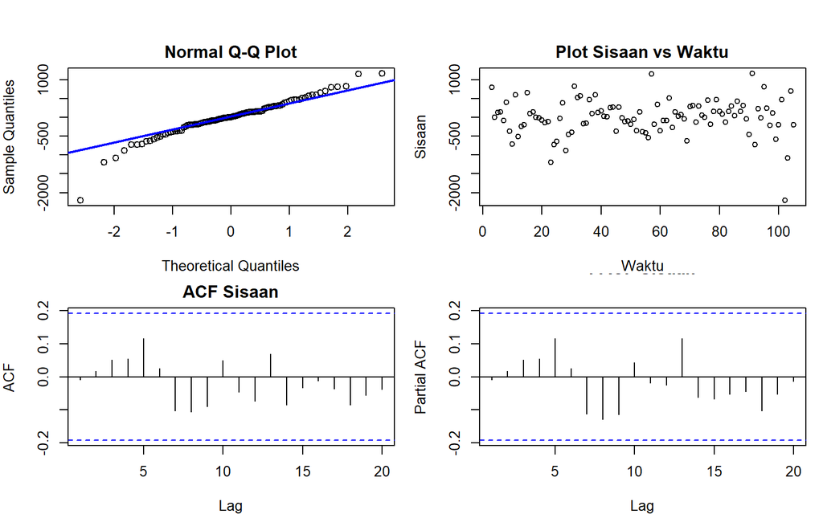

```r
sisaan <- model2$residuals

par(mfrow = c(2,2),
    mar = c(4,4,2,1),
    oma = c(0,0,2,0))

# Q-Q Plot
qqnorm(sisaan, main = "Normal Q-Q Plot")
qqline(sisaan, col = "blue", lwd = 2)

# Plot Sisaan vs Waktu
plot(sisaan, type = "p",
     main = "Plot Sisaan vs Waktu",
     xlab = "Waktu", ylab = "Sisaan")

# ACF
acf(sisaan, main = "ACF Sisaan")

# PACF
pacf(sisaan, main = "PACF Sisaan")
```

Berdasarkan plot kuantil-kuantil normal, secara eksploratif terlihat bahwa sisaan tidak sepenuhnya menyebar normal karena titik-titik cenderung menyimpang dari garis kemiringannya (slope). Selain itu, lebar pita sebaran sisaan tampak tidak seragam, yang mengindikasikan adanya heterogenitas ragam. Sementara itu, plot ACF dan PACF sisaan dari model ARIMA(1,2,1) menunjukkan tidak adanya spike signifikan pada 20 lag pertama, sehingga secara visual sisaan dapat dianggap saling bebas. Kondisi ini akan diuji lebih lanjut dengan uji formal.

### Uji Formal

```r
# Sisaan menyebar normal

ks.test(sisaan,"pnorm")
```

```
##
##  Asymptotic one-sample Kolmogorov-Smirnov test
##
## data:  sisaan
## D = 0.50485, p-value < 2.2e-16
## alternative hypothesis: two-sided
```

Berdasarkan uji KS tersebut, didapat p-value sebesar $0.0000$ yang kurang dari taraf nyata 5% sehingga tolak $H_0$ dan menandakan bahwa sisaan tidak menyebar normal. Hal ini sesuai dengan hasil eksplorasi menggunakan plot kuantil-kuantil normal.

```r
# Sisaan saling bebas

Box.test(sisaan, type = "Ljung")
```

```
##
##  Box-Ljung test
##
## data:  sisaan
## X-squared = 0.0083685, df = 1, p-value = 0.9271
```

Berdasarkan uji Ljung-Box tersebut, didapat p-value sebesar $0.9271$ yang lebih besar dari taraf nyata 5% sehingga gagal tolak $H_0$ dan menandakan bahwa sisaan saling bebas. Hal ini sesuai dengan hasil eksplorasi.

```r
# Sisaan homogen

Box.test((sisaan)^2, type = "Ljung")
```

```
##
##  Box-Ljung test
##
## data:  (sisaan)^2
## X-squared = 4.2512, df = 1, p-value = 0.03922
```

```r
# Nilai tengah sisaan sama dengan nol

t.test(sisaan, mu = 0, conf.level = 0.95)
```

```
##
##  One Sample t-test
##
## data:  sisaan
## t = 0.024091, df = 102, p-value = 0.9808
## alternative hypothesis: true mean is not equal to 0
## 95 percent confidence interval:
##  -92.22946  94.49741
## sample estimates:
## mean of x
##  1.133977
```

Berdasarkan uji-t tersebut, didapat p-value sebesar $0.9808$ yang lebih besar dari taraf nyata 5% sehingga tak tolak $H_0$ dan menandakan bahwa nilai tengah sisaan sama dengan nol. Hal ini berbeda dengan eksplorasi.

## Overfitting

Tahapan selanjutnya adalah overfitting dilakukan dengan menaikkan orde AR(p) dan MA(q) dari model ARIMA(1,2,1) Kandidat model overfitting adalah ARIMA(2,2,1) dan ARIMA(1,2,2).

### ARIMA(2,2,1)

```r
model5 = Arima(train.diff2, order=c(2,0,1), method="ML")
summary(model5)
```

```
## Series: train.diff2
## ARIMA(2,0,1) with non-zero mean
##
## Coefficients:
##          ar1     ar2      ma1     mean
##       0.2534  0.0429  -1.0000  -2.1565
## s.e.  0.0993  0.0996   0.0298   2.1763
##
## sigma^2 = 234888:  log likelihood = -783.02
## AIC=1576.04   AICc=1576.65   BIC=1589.21
##
## Training set error measures:
##                    ME     RMSE      MAE  MPE MAPE      MASE         ACF1
## Training set 1.308878 475.1485 336.6273 -Inf  Inf 0.4693648 7.030419e-05
```

```r
lmtest::coeftest(model5)
```

```
##
## z test of coefficients:
##
##            Estimate Std. Error  z value Pr(>|z|)
## ar1        0.253398   0.099252   2.5531  0.01068 *
## ar2        0.042934   0.099630   0.4309  0.66652
## ma1       -0.999998   0.029842 -33.5102  < 2e-16 ***
## intercept -2.156504   2.176257  -0.9909  0.32172
## ---
## Signif. codes:  0 '***' 0.001 '**' 0.01 '*' 0.05 '.' 0.1 ' ' 1
```

ARIMA(2,2,1) dengan menaikkan satu ordo AR ternyata tidak lebih baik dari Model ARIMA(1,2,1). Karena nilai AIC dari Model ARIMA(2,2,1) lebih besar serta ada parameter yang tidak signifikan yaitu ar2 dan intersep.

### ARIMA(1,2,2)

```r
model6 = Arima(train.diff2, order=c(1,0,2), method="ML")
summary(model6)
```

```
## Series: train.diff2
## ARIMA(1,0,2) with non-zero mean
##
## Coefficients:
##          ar1      ma1     ma2     mean
##       0.6475  -1.4271  0.4271  -2.3356
## s.e.  0.3437   0.4078  0.4069   2.5008
##
## sigma^2 = 234644:  log likelihood = -782.85
## AIC=1575.69   AICc=1576.31   BIC=1588.87
##
## Training set error measures:
##                    ME     RMSE      MAE  MPE MAPE      MASE       ACF1
## Training set 2.421893 474.9016 336.6613 -Inf  Inf 0.4694121 0.02774528
```

```r
lmtest::coeftest(model6)
```

```
##
## z test of coefficients:
##
##           Estimate Std. Error z value  Pr(>|z|)
## ar1        0.64753    0.34369  1.8840 0.0595590 .
## ma1       -1.42711    0.40778 -3.4997 0.0004657 ***
## ma2        0.42711    0.40695  1.0496 0.2939226
## intercept -2.33556    2.50080 -0.9339 0.3503428
## ---
## Signif. codes:  0 '***' 0.001 '**' 0.01 '*' 0.05 '.' 0.1 ' ' 1
```

ARIMA(1,2,2) dengan menaikkan satu ordo MA ternyata masih tidak lebih baik dari Model ARIMA(1,2,1). Karena nilai AIC dari Model ARIMA(1,2,2) lebih besar serta hanya satu parameter saja yang signifikan pada alpha 5% yaitu ma1.

Karena model hasil overfitting hasilnya tidak lebih baik daripada Model ARIMA(1,2,1), maka model terbaik yang dipilih adalah ARIMA(1,2,1) dilanjutkan dengan peramalan.

## Model Terbaik: ARIMA(1,2,1)

```r
model2 = Arima(train.diff2, order=c(1,0,1), method="ML")
summary(model2)
```

```
## Series: train.diff2
## ARIMA(1,0,1) with non-zero mean
##
## Coefficients:
##          ar1      ma1     mean
##       0.2644  -1.0000  -2.1568
## s.e.  0.0960   0.0307   2.0902
##
## sigma^2 = 232772:  log likelihood = -783.11
## AIC=1574.22   AICc=1574.63   BIC=1584.76
##
## Training set error measures:
##                    ME     RMSE      MAE  MPE MAPE      MASE         ACF1
## Training set 1.133977 475.3866 338.4555 -Inf  Inf 0.4719139 -0.008884057
```

```r
lmtest::coeftest(model2)
```

```
##
## z test of coefficients:
##
##            Estimate Std. Error  z value  Pr(>|z|)
## ar1        0.264411   0.095952   2.7557  0.005857 **
## ma1       -0.999998   0.030694 -32.5796 < 2.2e-16 ***
## intercept -2.156806   2.090245  -1.0318  0.302145
## ---
## Signif. codes:  0 '***' 0.001 '**' 0.01 '*' 0.05 '.' 0.1 ' ' 1
```

Nilai AIC: $1574.22$  
Nilai AICc: $1574.63$  
Nilai BIC: $1584.76$  
Parameter ar1 dan ma1 signifikan pada taraf nyata 5%

## Peramalan

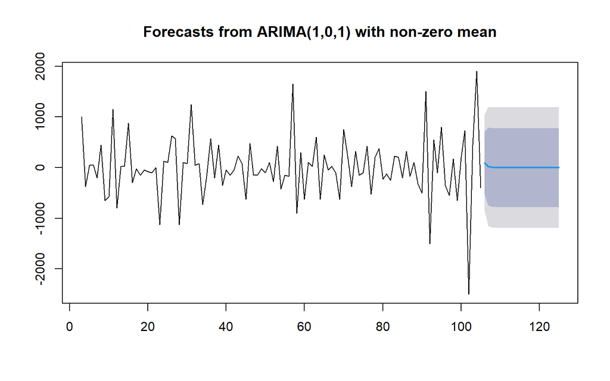

```r
ramalan <- forecast::forecast(model2, h = length(test.ts))

data.ramalan <- ramalan$mean
plot(ramalan)
```

```r
# Inverse differencing
pt_akhir_train <- tail(train.ts, 2)

forecast <- diffinv(data.ramalan, differences = 2, xi = pt_akhir_train)
hasil <- forecast[-c(1,2)]
hasil <- forecast[1:length(test.ts)]

# Bandingkan aktual vs forecast
perbandingan <- cbind(
  Aktual   = test.ts,
  Forecast = hasil
)

print(head(perbandingan, 10))
```

```
## Time Series:
## Start = 1
## End = 10
## Frequency = 1
##      Aktual Forecast
##  1 7296.712 7221.746
##  2 7171.769 6971.859
##  3 6597.027 6815.925
##  4 6796.938 6683.246
##  5 6971.859 6555.130
##  6 6846.915 6426.634
##  7 6946.870 6296.451
##  8 6746.960 6164.236
##  9 6696.982 6029.896
## 10 6597.027 5893.408
```

```r
akurasi_test <- accuracy(hasil, test.ts)
akurasi_test
```

```
##               ME     RMSE     MAE     MPE     MAPE      ACF1 Theil's U
## Test set 1117.56 1480.609 1139.45 15.8139 16.14571 0.8173827  6.087988
```

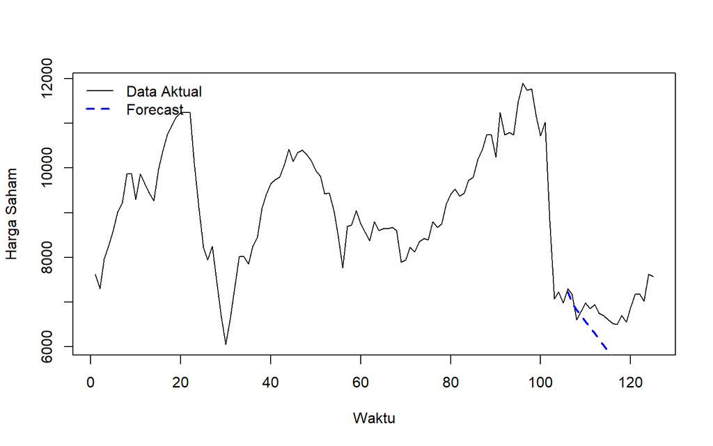

```r
ts.plot(dt, col = "black", lty = 1,
        xlab = "Waktu", ylab = "Harga Saham")

lines(106:(105+length(hasil)), hasil, col = "blue", lty = 2, lwd = 2)
legend("topleft",
       legend = c("Data Aktual", "Forecast"),
       col = c("black", "blue"),
       lty = c(1,2,3), lwd = c(1,2,1), bty = "n")
```

Berdasarkan hasil peramalan, dapat dilihat bahwa nilai MAPE yang didapatkan sebesar 16,15% yang sebenarnya masih cukup baik untuk model tersebut, tetapi dikarenakan nilai ACF1 dan Theil’s U yang besar menunjukkan model belum menangkap pola autokorelasi residual dengan baik. Peramalan ini hanya cocok untuk jangka pendek.